# Community Contribution

Haofeng Chen

3/25/2019

```r
setwd("~/Desktop/GR5206/Homework/HW1")
titanic <- read.table("Titanic.txt",as.is = TRUE,header = TRUE)
```

Filter out NA entry

```r
titanic <- titanic[!is.na(titanic$Age),]
write.csv(titanic,'titanic_clean.csv')
for (i in 1:nrow(titanic)){
  if (titanic$Survived[i] == 0){titanic$Survived_Status[i] <- "dead"}
  else {titanic$Survived_Status[i] <- "survived"}
}
```

Bar Chart

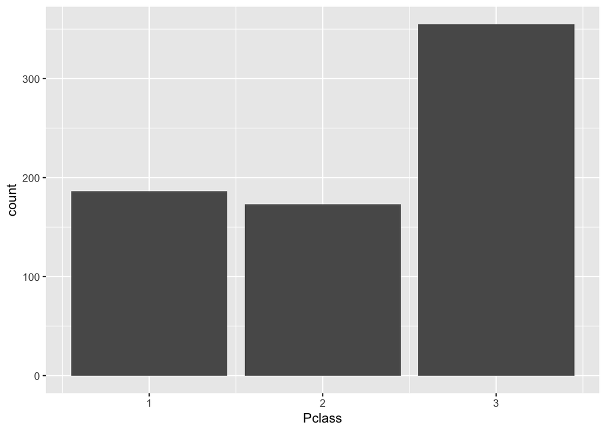

```r
library(ggplot2)
ggplot(titanic)+
  geom_bar(mapping = aes(Pclass))
```

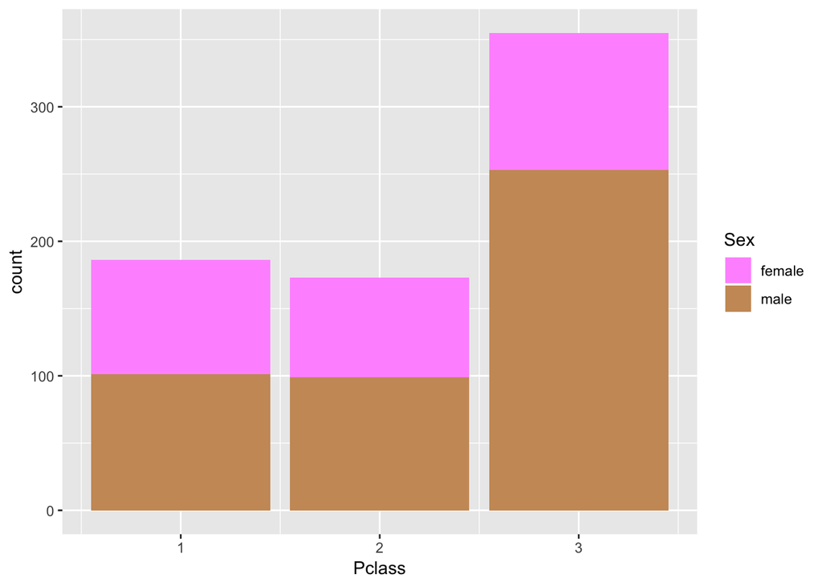

```r
color = c("#ff99ff", "#cc9966")
ggplot(titanic)+
  geom_bar(mapping = aes(Pclass,fill = Sex))+
  scale_fill_manual(values = color)
```

Histogram

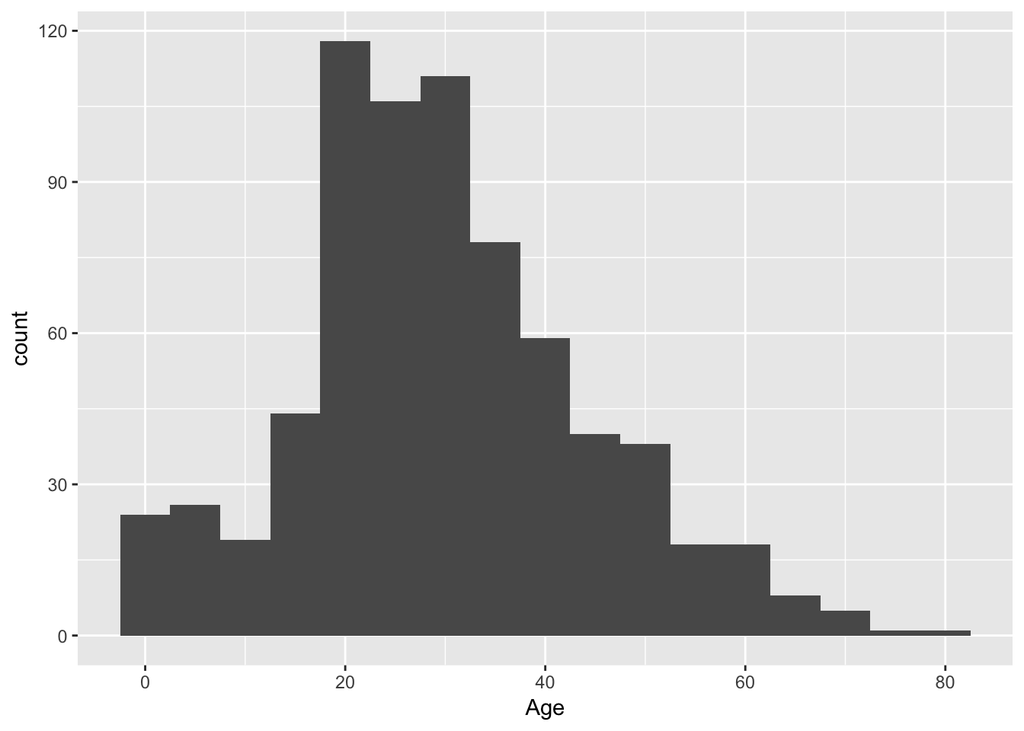

```r
ggplot(titanic)+
  geom_histogram(mapping = aes(Age),binwidth = 5)
```

Boxplot

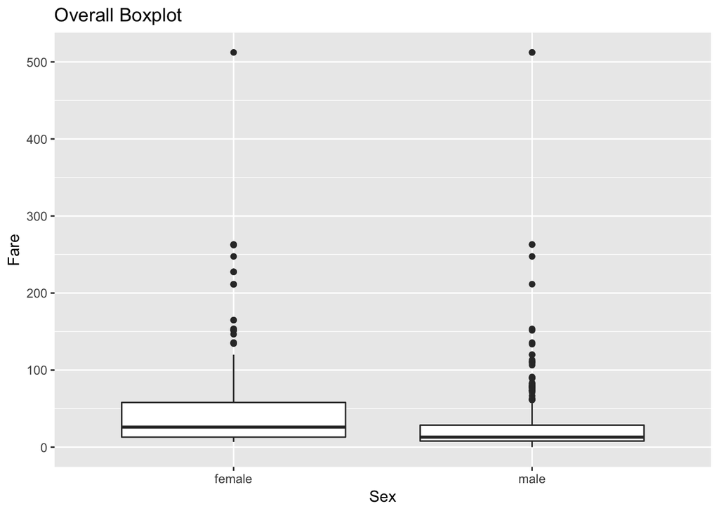

```r
library(ggplot2)
library(tidyverse)
ggplot(titanic, aes(Sex, Fare)) + geom_boxplot()+
  ggtitle("Overall Boxplot")
```

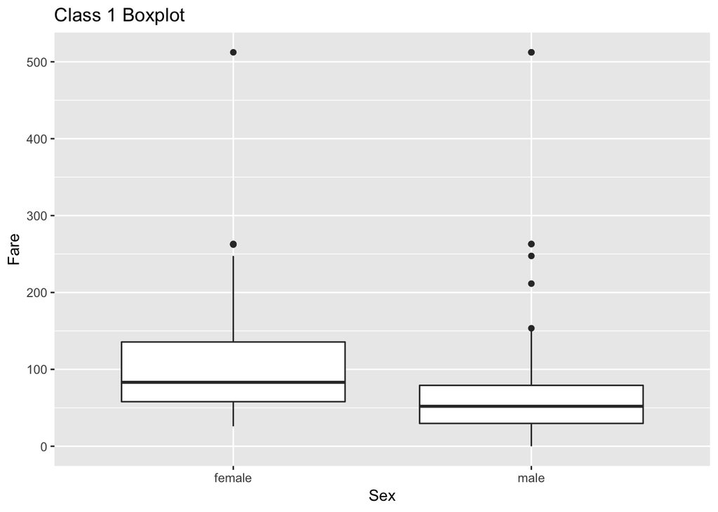

```r
titanic_class_1 = titanic[titanic$Pclass == 1,]
titanic_class_2 = titanic[titanic$Pclass == 2,]
titanic_class_3 = titanic[titanic$Pclass == 3,]
ggplot(titanic_class_1, aes(Sex, Fare)) + geom_boxplot()+
  ggtitle("Class 1 Boxplot")
```

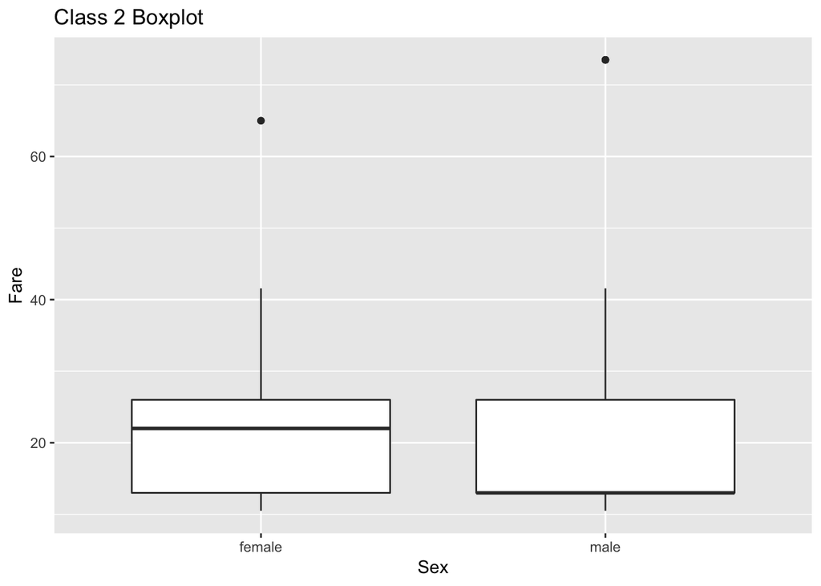

```r
ggplot(titanic_class_2, aes(Sex, Fare)) + geom_boxplot()+
  ggtitle("Class 2 Boxplot")
```

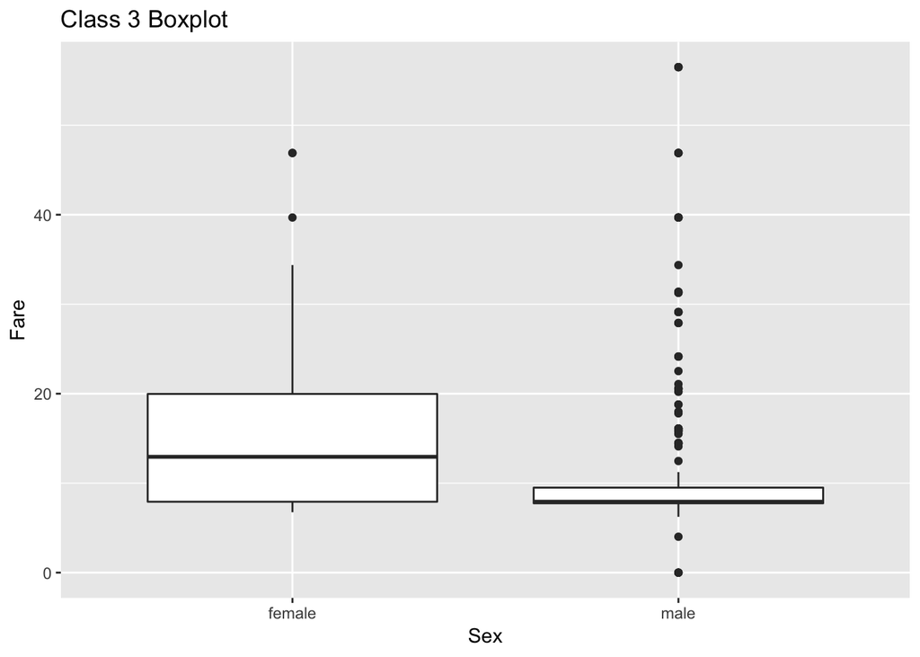

```r
ggplot(titanic_class_3, aes(Sex, Fare)) + geom_boxplot()+
  ggtitle("Class 3 Boxplot")
```

Mosaic

```r
library(vcd)
```

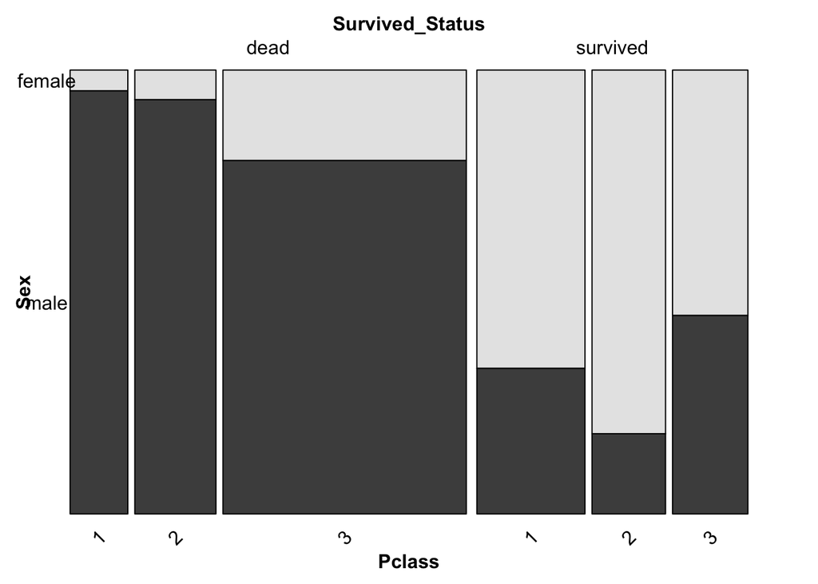

```r
vcd::mosaic(Sex~ Survived_Status + Pclass, titanic,
            direction = c("v", "v", "h"),
            labeling = labeling_border(rot_labels = c(0, 0, 45, 0)))
```

Couple noted comparision:

1. R is ideal for data cleaning while Tableau is designed for visualizing tidy data. For example, Tableau may have a hard time reading data in txt format.
2. In terms of bar chart, Tableau is mainly clicking and dragging variables using mouse with optional coding, whereas Rstuidio is all coding. Therefore, if you want to take a look at certain graph quickly, Tableau will be a ideal software. However, if you need complicate data cleaning or manipulation (grouping,selecting), RStudio perhaps will be more optimal.
3. The choices of graphs are suggested in Tableau, however, this could limited your graphing choices. For example, Tableau just don’t have mosaic plot, and since it is not a open source programming language, you can only count on Tableau’s in-house development team to provide mosaic plot in the future. However, this is not the case for RStudio, given the fact that it is a open-source programming language.